# Lab 2 Dan

Main data cleaning:

```r
#Remove ID duplicates:
fifa.cleaned <- fifa %>% filter(duplicated(fifa$ID) == FALSE)
```

Question 1:

*** Basic univariate statistics:

1.a - Make a plot showing the `overall` ability distribution of all players. How skewed is the distributions? does it have fat tails?  
Plot on top of the `overall` distribution a Normal distribution matching its first two moments. Is the distribution described well by a Normal distribution? explain.

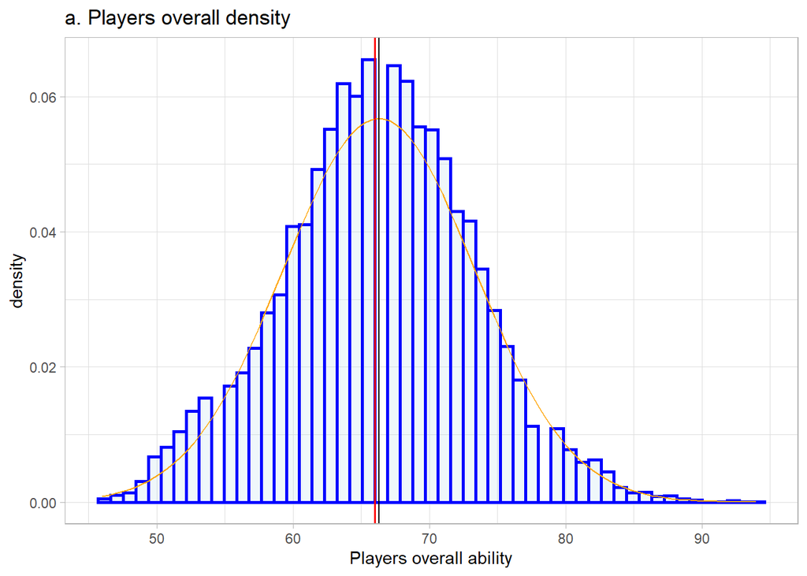

```r
attach(fifa_players)
ggplot(data = fifa.cleaned,aes(x = Overall))+
  geom_histogram(aes(y=..density..),col = "blue", fill = "lightblue", lwd = 0.9,bins = 53,
  alpha = 0.2)+ stat_function(fun = dnorm,args = list(mean = mean(Overall),sd = sd(Overall)),
      col = "orange", lwd = 0.5) + theme_light()+ xlab("Players overall ability") + labs(title="a. Players overall density") +
  geom_vline(xintercept = median(Overall),col = "red",lwd = .7) +
  geom_vline(xintercept = mean(Overall),col = "black",lwd = .5)
```

We’ll smooth the data so that it’s easier to understand the data. In the graph above the median was marked in red, and the mean was marked in black. we can see that they are almost equal as we have in a normal distribution.

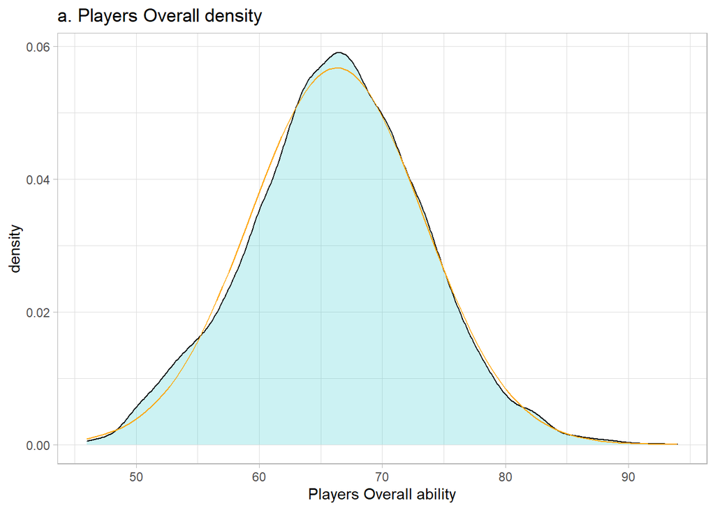

```r
ggplot(data = fifa_players,aes(x= Overall))  + geom_density(fill="#00Bfc4",alpha=0.2)+
  stat_function(fun = dnorm, args = list(mean = mean(fifa_players$Overall), sd = sd(fifa_players$Overall)), col="orange", lwd = 0.5) +
  xlab("Players Overall ability")+
  ylab("density")+
  labs(title="a. Players Overall density")+
  theme_light() +
  scale_colour_economist()
```

As we see in the graph the distribution has a slightly long right tail and a relatively short left tail. Still, the skeweness is not very high around the mean. So we can say that the density of the overall distribution does correspond similarly to a normal density with the values corresponding to the expectation of the variance. We see some anomalies in respect to normal density but they insignificant so the distribution described can be reffered to as a normal distribution.

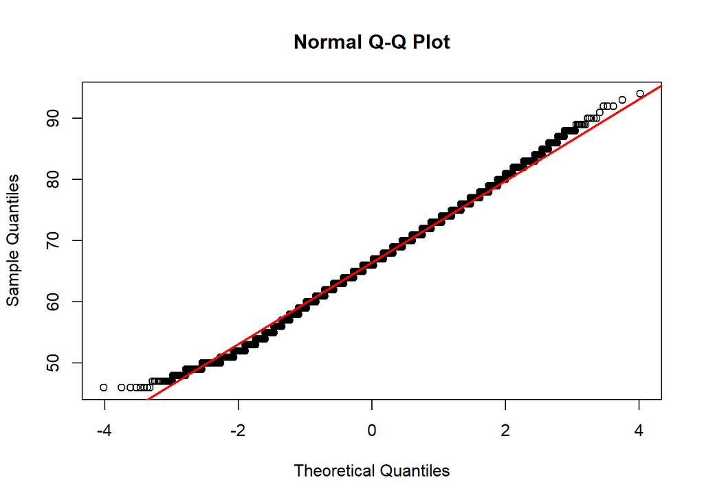

```r
qqnorm(players.Overall)
qqline(players.Overall, col = "red", lwd = 2)
```

** *1.b - Make a plot comparing the multiple `overall` ability* distributions* of players according to the `continent` of the players. Describe which continents have especially good/bad players.

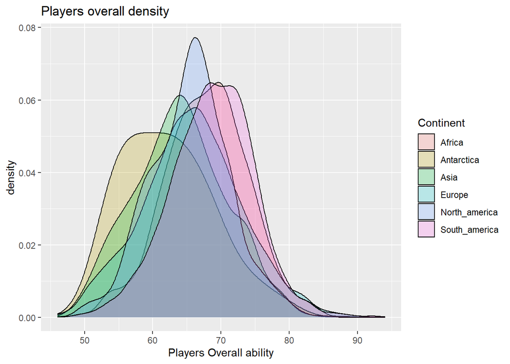

```r
fifa$Continent <- factor(fifa$Continent)
ggplot(fifa, aes(Overall)) +geom_density(aes(fill= Continent), alpha=0.24) +xlab("Players Overall ability")+
  ylab("density")+ggtitle("Players overall density")
```

To make it distinct we’ll use another type of graph:

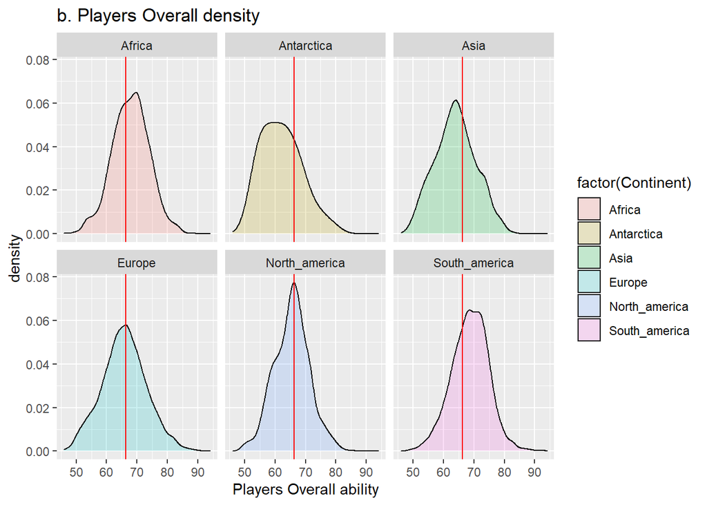

```r
ggplot(data = fifa_players,aes(x= Overall)) + geom_density(aes(fill= factor(Continent)), alpha=0.2)+
  xlab("Players Overall ability")+
  ylab("density")+
  labs(title="b. Players Overall density")+
  facet_wrap(~ Continent, ncol = 3) + geom_vline(xintercept = mean(Overall), col= "red", lwd = 0.5)
```

Now we can review more clearly the data of each continent. However it is still quite difficult to compare between them, we’ll use a boxplot to try and rearrange it differently:

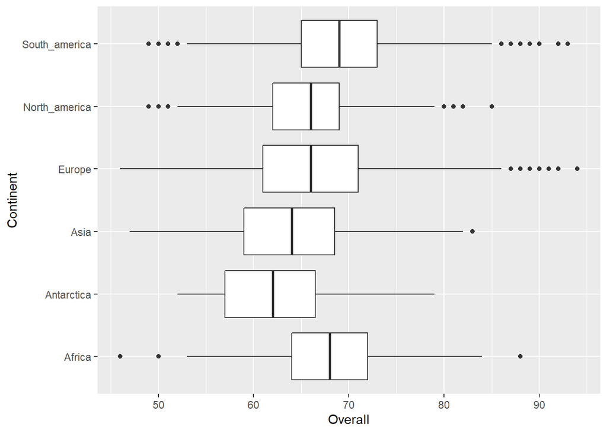

```r
ggplot(fifa,aes(x=Continent,y=Overall))+
  geom_boxplot()+
  ylab("Overall")+
  coord_flip()
```

As we can see clearly from the boxplot, the south-american players are better than the rest of the players in world. we can also see that the antartican players are generally worse than the rest of the world.  
** 1.c - Make a plot showing the density of players’ `value` distribution.  
Next, make a separate plot showing the density distribution of the log* of players’ `value`.  
Which of the two visualizations is better? explain.

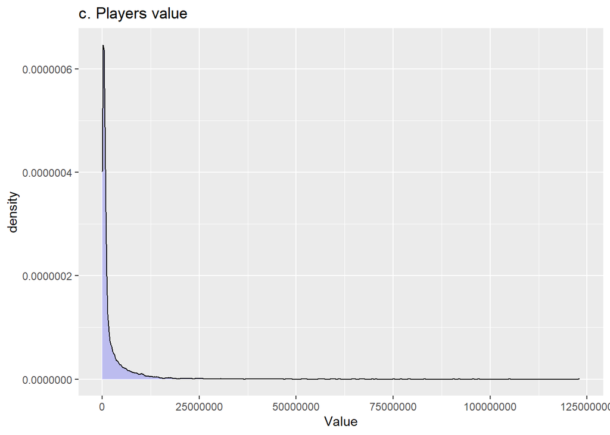

[figure not shown]

```r
fifa %>%
  ggplot(aes(Value)) +
  geom_density(alpha=.2, fill= "blue") + labs(title="c. Players value")
```

It is almost impossible to make conclusions from the first graph - because the differences in the value of the players are high we get a very big drop in the plot but not very much information about the subtle trends. That’s why using the log function makes it more clear - the differences become less significant and the trend seems more smooth and then it’s easier to analyze.  
*** 1.d - Are the top-10 players with the highest `value` also the top-10 best players in terms of `overall` ability? Show tables for both and compare.  
Who is the best player not in the top-10 valued players?

```r
top_ten_Value <- fifa_players %>% select(Name,Overall, Value) %>% top_n(10, Value) %>% arrange(desc(Value))
knitr::kable(head(top_ten_Value,10), caption = "Most valued players.")
```

Most valued players.

| Name | Overall | Value |
| --- | --- | --- |
| Neymar | 92 | 123000000 |
| L. Messi | 93 | 105000000 |
| L. Suárez | 92 | 97000000 |
| Cristiano Ronaldo | 94 | 95500000 |
| R. Lewandowski | 91 | 92000000 |
| E. Hazard | 90 | 90500000 |
| K. De Bruyne | 89 | 83000000 |
| P. Dybala | 88 | 79000000 |
| T. Kroos | 90 | 79000000 |
| G. Higuaín | 90 | 77000000 |

```r
top_ten_Overall <- fifa_players %>% select(Name, Overall, Value) %>% top_n(10, Overall) %>% arrange(desc(Overall))
knitr::kable(head(top_ten_Overall,10), caption = "Most valued players.")
```

| Name | Overall | Value |
| --- | --- | --- |
| Cristiano Ronaldo | 94 | 95500000 |
| L. Messi | 93 | 105000000 |
| Neymar | 92 | 123000000 |
| M. Neuer | 92 | 61000000 |
| L. Suárez | 92 | 97000000 |
| R. Lewandowski | 91 | 92000000 |
| E. Hazard | 90 | 90500000 |
| De Gea | 90 | 64500000 |
| G. Higuaín | 90 | 77000000 |
| T. Kroos | 90 | 79000000 |

The best player not in the top 10 valued players is: M. Neuer.  
** *1.e - Show a table of the* 10* *youngest* and *10* *oldest* teams in terms of *average* players `age`.

We’ll start with the youngest teams:

```r
mean_age <- fifa %>% group_by(Club) %>% summarise(mean=mean(Age))
arrange(mean_age, mean)[1:10,]
```

```
## # A tibble: 10 x 2
##    Club               mean
##    <chr>             <dbl>
##  1 Sevilla AtlÃ©tico  19.8
##  2 FC Barcelona B     20.4
##  3 Werder Bremen II   21.5
##  4 LOSC Lille         21.6
##  5 PSV                21.9
##  6 Crewe Alexandra    21.9
##  7 FC NordsjÃ¦lland   22
##  8 Ajax               22.1
##  9 KRC Genk           22.1
## 10 Barnsley           22.1
```

Now the oldest teams:

```r
arrange(mean_age, -mean)[1:10,]
```

```
## # A tibble: 10 x 2
##    Club                                 mean
##    <chr>                               <dbl>
##  1 Brisbane Roar                        31
##  2 Newcastle Jets                       31
##  3 FC Seoul                             30.8
##  4 Western Sydney Wanderers             30.8
##  5 AssociaÃ§Ã£o Chapecoense de Futebol  30.6
##  6 Adelaide United                      30.4
##  7 Jeonbuk Hyundai Motors               30.3
##  8 Clube AtlÃ©tico Paranaense           30
##  9 GrÃªmio Foot-Ball Porto Alegrense    30
## 10 Sydney FC                            30
```

Question 2:

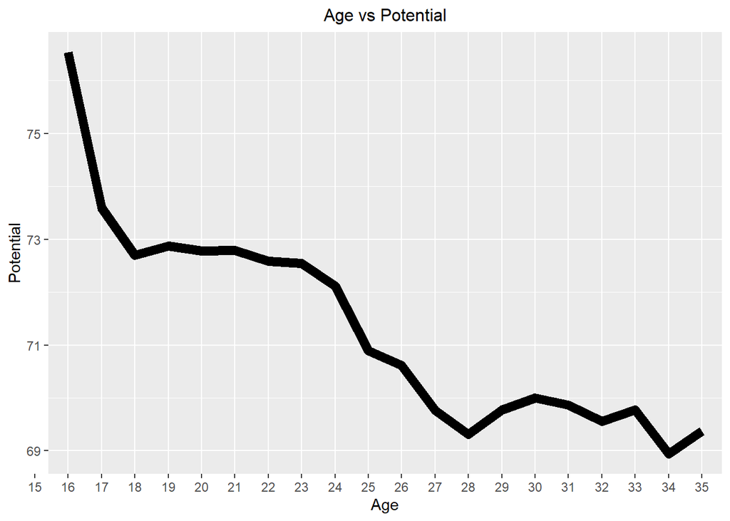

```r
#Targeting Age <=35:
q2a <- fifa.cleaned %>% select(Potential,Age) %>% filter(Age <= 35)
q2a = aggregate(q2a,
           by = list(q2a$Age),
           FUN = mean)
#Plotting results:
ggplot(q2a,aes(x=Age))+ ggtitle("Age vs Potential")+
theme(plot.title = element_text(hjust = 0.5, size = 12))+
geom_line(aes(y=Potential),size = 3)+
scale_x_discrete(limits=c(15:35))
```

***  
2.b - The average difference between a player’s overall ability to potential ability as a function of age, up to age 35. To see that, we used the aggregate function as a function of age. The rest of the code is visual modificaitons to the graph.

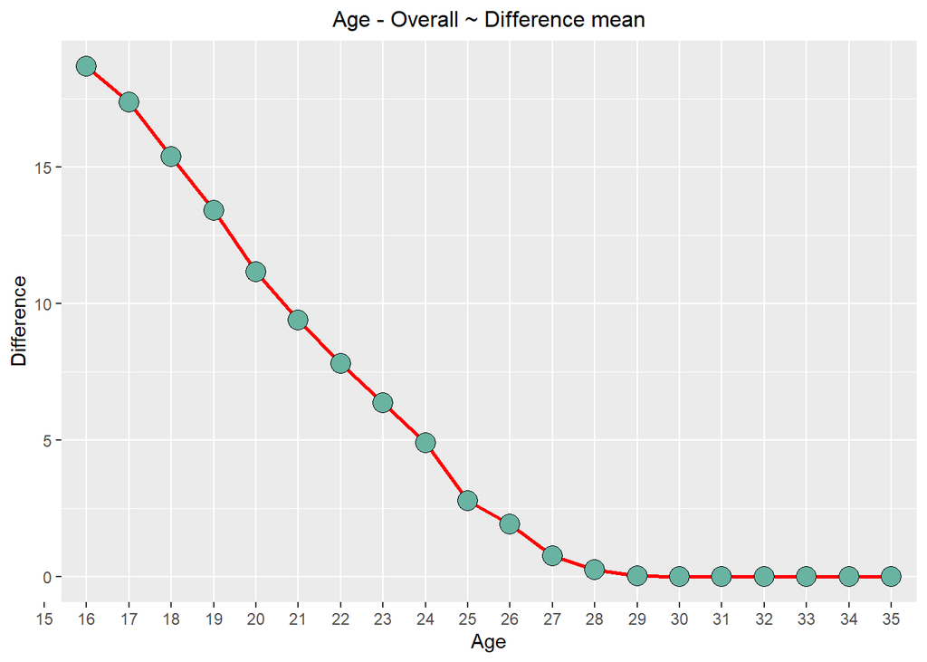

```r
q2b <-fifa.cleaned %>% select(Overall,Potential,Age) %>% filter(Age <= 35)
q2b$Difference = abs(q2b$Potential - q2b$Overall)
q2b = aggregate(q2b,
           by = list(q2b$Age),
           FUN = mean)


ggplot(q2b,aes(x=Age, y=Difference))+
ggtitle("Age - Overall ~ Difference mean", )+
theme(plot.title = element_text(hjust = 0.5, size = 12))+
geom_line(size = 1,color="red")+
geom_point(shape=21, color="black", fill="#69b3a2", size=5)+
scale_x_discrete(limits=c(15:35))
```

Based on the graph, We can see that players usually develop until the age of 30. The mean difference for players that are 30 and above is 0. Thus, we won’t expect those players to have any future development.  
***  
2.c - We are seeking for young (age≤21) players with high potential (potential>70). The next plot shows players potential abillity (x - axis) and their current value:

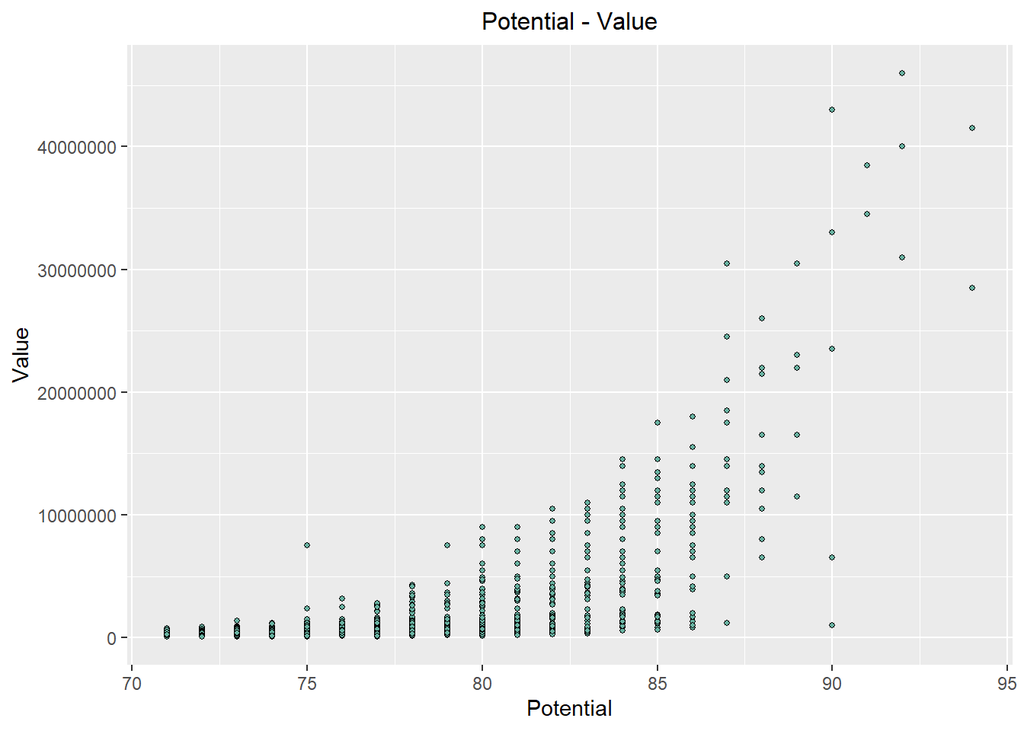

```r
q2c <- fifa.cleaned %>% select(Name,Potential,Age, Value) %>%  filter(Potential > 70, Age <= 21, Value >0)
#We added value>0 ti aviod zero values

ggplot(q2c,aes(x=Potential, y=Value))+
ggtitle("Potential - Value", )+
theme(plot.title = element_text(hjust = 0.5, size = 12))+
geom_point(shape=21, color="black", fill="#69b3a2", size=1)
```

Now, we will create a linear model and try to figure out the top 10 undervalued players by observing their residuals compared to the rest:

```r
q2c_lm <- lm(Potential ~ Value, data = q2c)
q2c_res  = residuals(q2c_lm)
top_10_undervalued <- q2c_res %>% order(q2c_res,decreasing = TRUE)
#Getting top 10 (indices):
top_10_undervalued <- top_10_undervalued[1:10]
result_q2c = data.frame()
j = 1
for (i in top_10_undervalued){
  result_q2c <- rbind(result_q2c ,q2c[i,])
  j = j+1
}
```

Top 10 undervalued players:

```r
print(result_q2c)
```

```
##                Name Potential Age   Value
## 229        A. Gomes        90  16  975000
## 307      M. Edwards        87  18 1200000
## 567       J. Sancho        86  17  800000
## 600     C. FrÃ¼chtl        86  17  975000
## 1619       E. Barco        90  18 6500000
## 183    R. Sessegnon        86  17 1300000
## 305        J. Foyth        86  19 1700000
## 1914 E. Abouchabaka        85  17  650000
## 1912   D. Upamecano        86  18 2000000
## 402        V. Thill        85  17  800000
```

It seems that usually younger players are the most undervalued. Now, we’d like to show those players the “fair value” that they could’ve got by adding a new column to the previous table :

```r
q2c_lm2 <- lm(Value ~ Age + Potential  ,data = q2c)
#Creating a new column that contains the fitted values for the players from previous section:
fitted_player_values = c()
j = 1
i = 1
for (i in top_10_undervalued){
  fitted_player_values <- rbind(fitted_player_values ,q2c_lm2$fitted.values[i])
  j = j+1
}
```

```r
result_q2c <- cbind(result_q2c,fitted_player_values)
colnames(result_q2c)[5] <- "Fitted"
result_q2c
```

```
##                Name Potential Age   Value  Fitted
## 229        A. Gomes        90  16  975000 6937841
## 307      M. Edwards        87  18 1200000 6536705
## 567       J. Sancho        86  17  800000 5357045
## 600     C. FrÃ¼chtl        86  17  975000 5357045
## 1619       E. Barco        90  18 6500000 8192978
## 183    R. Sessegnon        86  17 1300000 5357045
## 305        J. Foyth        86  19 1700000 6612182
## 1914 E. Abouchabaka        85  17  650000 4804954
## 1912   D. Upamecano        86  18 2000000 5984614
## 402        V. Thill        85  17  800000 4804954
```

***  
2.d - We would like to fly abroad to recruit promising players. to find good locations, We want to create a map of the world which has the countries colored based on the median potential of the player. After we checked that there’s no rows that could cause errors (NA’S, NaNs etc…), We created a dataset that fits the required data:

```r
q2d <-  fifa.cleaned %>% select(Nationality, Potential)
q2d = aggregate(Potential ~ Nationality ,data = q2d, FUN = median, na.action = drop)
colnames(q2d)[2] <- "Local Potential Median"
head(q2d) #Displaying samples
```

```
##   Nationality Local Potential Median
## 1 Afghanistan                   65.0
## 2     Albania                   71.0
## 3     Algeria                   73.0
## 4      Angola                   72.0
## 5   Argentina                   72.0
## 6     Armenia                   70.5
```

Now that we have the data ready, we can create a map using rworldmap:

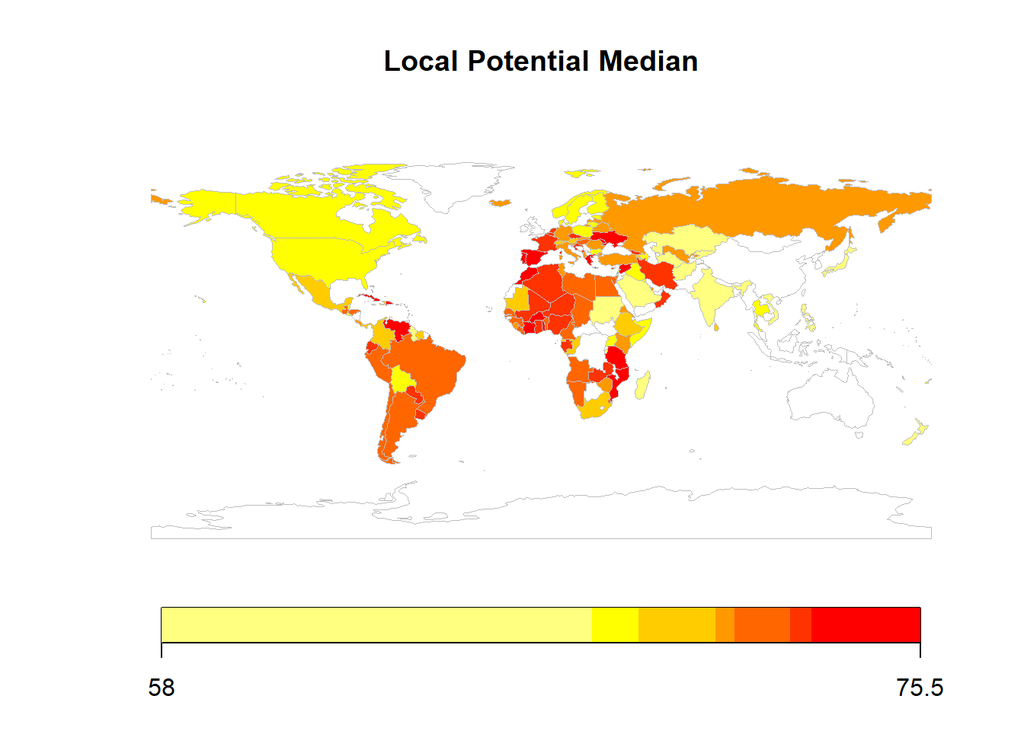

***  
2.e - In this section, We repeated the same analysis but this time displayed a world map that each country is colored by the median ratio of potential to value of players. Our goal is to find an under-valued country to recommend to scout in (i.e. a country with cheap players compared to their potential average quality).

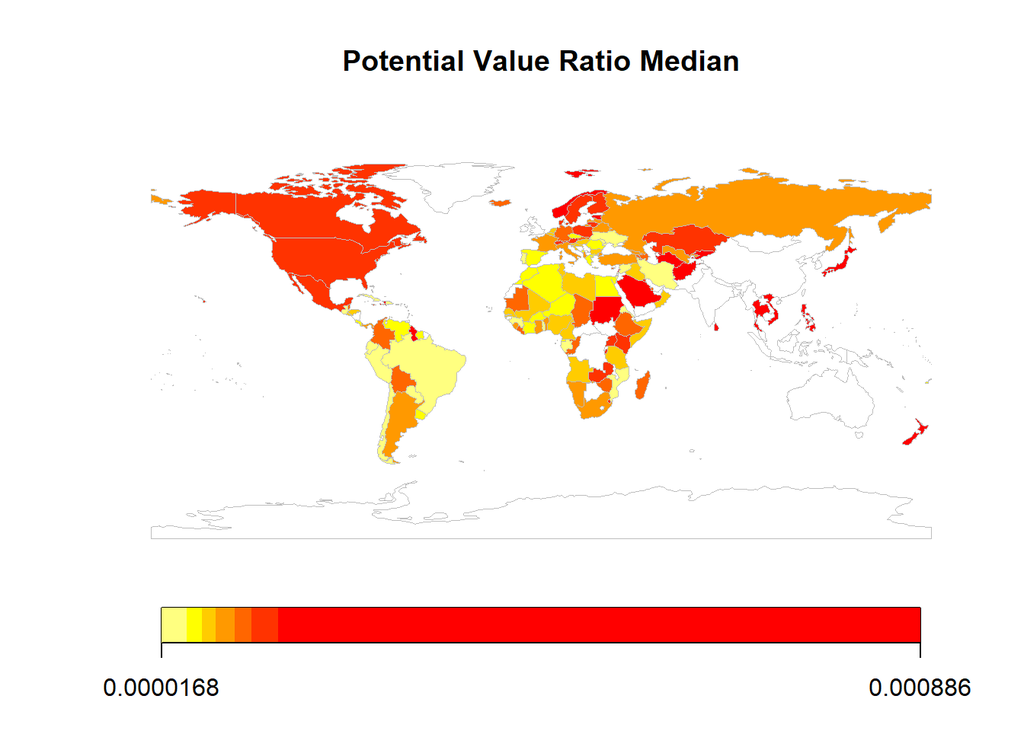

```r
q2e <-  fifa.cleaned %>% select(Nationality, Value ,Potential)
Potential_Value_Ratio <-  q2e$Potential/q2e$Value #This calculation causes Inf values to appear so we have to clean them.
q2e <- cbind(q2e,Potential_Value_Ratio)
q2e <- q2e[!is.infinite(Potential_Value_Ratio),]
q2e = aggregate(Potential_Value_Ratio ~ Nationality ,data = q2e, FUN = median, na.action = drop)
colnames(q2e)[2] <- "Potential Value Ratio Median"
```

If we look at the list that represents the best countries (red), we have to pick one of them so we can recommend the boss a good location for scouting players:

```
##           Nationality Potential Value Ratio Median
## 1          San Marino                    0.0008857
## 2          Kyrgyzstan                    0.0004462
## 3 Republic of Ireland                    0.0003364
## 4         Afghanistan                    0.0003333
## 5              Guyana                    0.0003211
```

San Marino allegedly seems the best place to go, but it’s a very small country and the median might not reflects the amount of good potentials there. Thus, I’d recommend my boss to visit Kyrgystan which is around the same amount of population as Ireland and has pretty good ratio between potential and value.

Question 3:

3a - We are interested in finding out which positions are similar in terms of players’ performance.  
Extract the 26 non-goalkeeper positions (`CAM, CB, ..., ST`). Calculate the correlation between players’ ability in each pair of positions and show a heatmap correlation-plot of the correlations’ matrix. What three positions have the *least* average correlations with other positions?

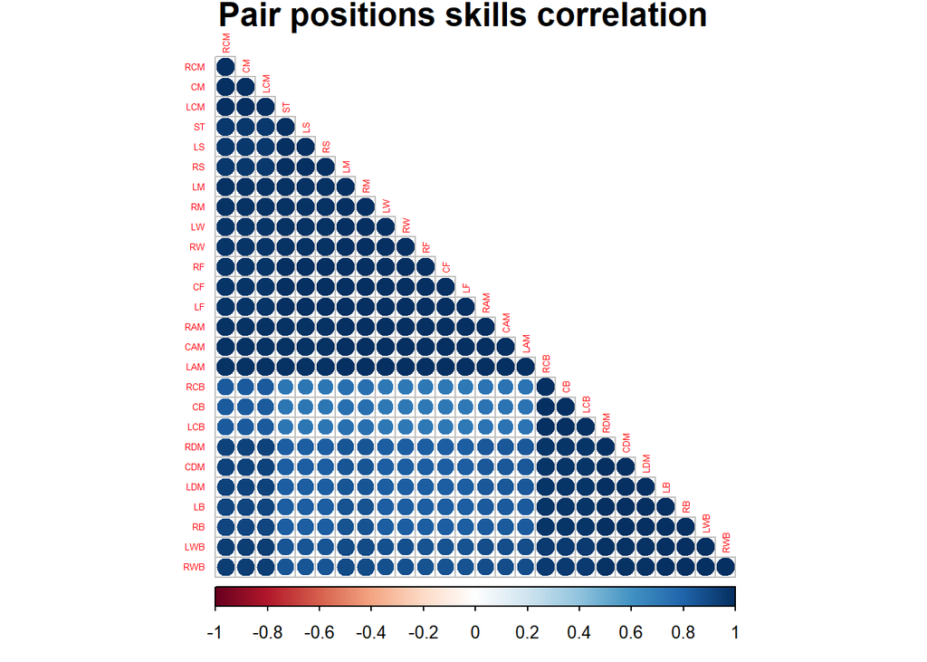

```r
pos_correlation <- cor(fifa_players_positions[-c(1,28:30)])

corrplot(pos_correlation,order = "hclust",tl.col = "red",tl.cex = 0.4,title = "Pair positions skills correlation",cex.main = 1.5, cl.cex=0.8, pch.cex = 0.6,type = "lower", mar=c(0, 0, 1, 0))
```

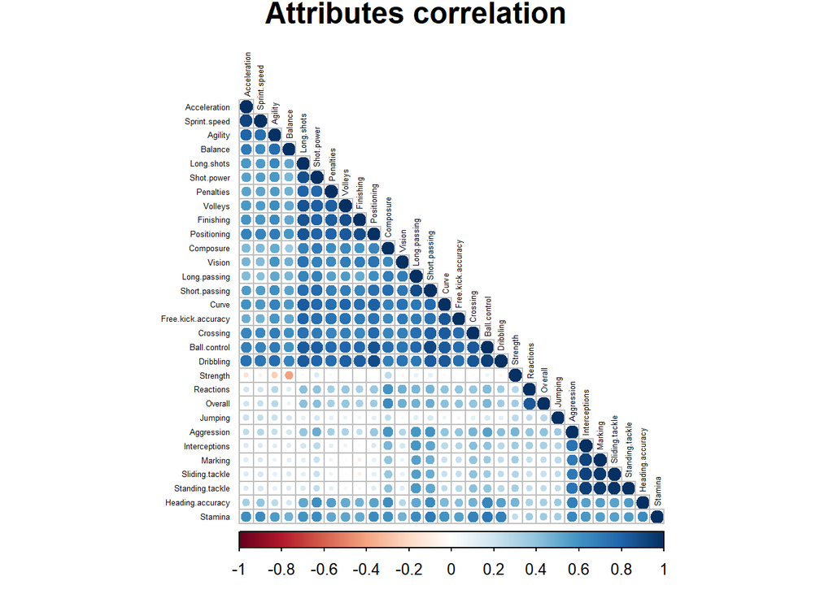

```r
attr_correlation <-  cor(fifa_players_attribures[-c(1,13:17)])
corrplot(attr_correlation,order = "hclust",tl.col = "black",tl.cex = 0.4,title = "Attributes correlation",cex.main = 1.5, cl.cex=0.8, pch.cex = 0.6,type = "lower", mar=c(0, 0, 1, 0))
```

As we can see from the heat-map graph the three positions which have the least average correlations with other positions are - “RCB”, “CB” and “LCB”. We can also deduce that strength and jumping least correlate with other attributes.  
**  
*3.b - Consider the following indicators of players performance: `overall` players’ performance, their `potential`, their salary (`wage`) and their market `value`. Show a correlation-plot of players’* 34* skill levels (`Acceleration`, …, `Volleys`) vs. these four indicators. Find the *10* skills with the highest *average* correlation with the four inidcators and list them in a table.

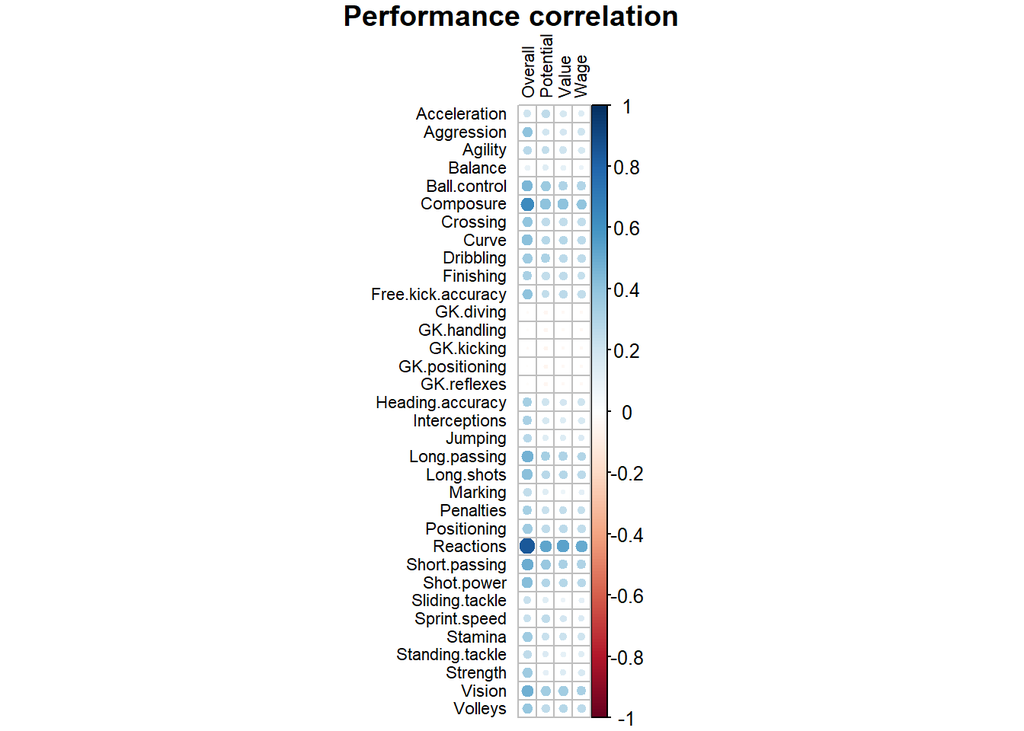

```r
performence_correlation <- cor(fifa_players_attribures[-c(1,36)],fifa_players_indicators[-1])
corrplot(performence_correlation,tl.col = "black",tl.cex = 0.7,title = "Performance correlation",cex.main = 1.2, mar=c(0, 0, 1, 0), cl.ratio = 1, cl.cex=0.8)
```

```r
performence_correlation <- as.data.frame(performence_correlation)
performence_correlation["average"] <- (performence_correlation$Overall+performence_correlation$Potential+performence_correlation$Value+ performence_correlation$Wage)/4
```

In the table below are shown the 10 skills with the highest average correlation with “Overall”, “Potential”, “Wage” and “Value”:

```r
knitr::kable(top_n(performence_correlation,10,average) %>% select(average) %>% arrange(desc(average)), caption = "The ten skills with the highest average correlation:")
```

The ten skills with the highest average correlation:

|  | average |
| --- | --- |
| Reactions | 0.5994 |
| Composure | 0.4576 |
| Short.passing | 0.3749 |
| Vision | 0.3745 |
| Ball.control | 0.3555 |
| Long.passing | 0.3502 |
| Shot.power | 0.3176 |
| Curve | 0.3143 |
| Long.shots | 0.3090 |
| Dribbling | 0.2994 |

```r
indicators <- c("Overall", "Potential", "Wage", "Value")
performance <- fifa[indicators]
skills <- fifa_players_attribures[c(2:35)]
cor_skills_indicators <- as.data.frame(cor(skills,performance))
ans <- data.frame(sort(rowMeans(cor_skills_indicators),decreasing = T) %>% head(10))
names(ans) <- "mean"
```

**  
*3.c - Build a team of* 11 different* players …

```r
positions <- fifa_players_positions[c(1:27)]
pos_names <- names(positions)[2:27]
```

Goal Keeper:

```r
goalie <- subset(fifa,grepl("GK",Preferred.Positions))
goalie[which.max(goalie$Overall),]
```

```
##          ID     Name Age Nationality Continent Overall Potential
## 2433 167495 M. Neuer  31     Germany    Europe      92        92
##                  Club                                 League    Value   Wage
## 2433 FC Bayern Munich Germany 1. Bundesliga in last 15 years 61000000 230000
##      Acceleration Aggression Agility Balance Ball.control Composure Crossing
## 2433           58         29      52      35           48        70       15
##      Curve Dribbling Finishing Free.kick.accuracy GK.diving GK.handling
## 2433    14        30        13                 11        91          90
##      GK.kicking GK.positioning GK.reflexes Heading.accuracy Interceptions
## 2433         95             91          89               25            30
##      Jumping Long.passing Long.shots Marking Penalties Positioning Reactions
## 2433      78           59         16      10        47          12        85
##      Short.passing Shot.power Sliding.tackle Sprint.speed Stamina
## 2433            55         25             11           61      44
##      Standing.tackle Strength Vision Volleys CAM CB CDM CF CM LAM LB LCB LCM
## 2433              10       83     70      11   0  0   0  0  0   0  0   0   0
##      LDM LF LM LS LW LWB RAM RB RCB RCM RDM RF RM RS RW RWB ST
## 2433   0  0  0  0  0   0   0  0   0   0   0  0  0  0  0   0  0
##      Preferred.Positions
## 2433                 GK
```

A function to build the best team:

```r
TeamConst <- function(df=fifa, positions){
  team = data.frame()

  for (pos in positions) {
    col_number = which(names(df) == pos)
    Candidates = df[which(df[,col_number]==max(df[,col_number]) ),]
    if (nrow(Candidates)>1) {
      Candidates = Candidates[which.max(Candidates$Overall),]
    }
    df = df[-which(df$ID == Candidates$ID),]

    if (nrow(team)==0) {
      team = Candidates
    }
    else{
      team = rbind(team,Candidates)
    }
  }
  return(team)
}
```

Activating the function to build the team:

```r
Besteam <-  TeamConst(positions = pos_names)

BestPlayersID <- Besteam[,c("ID","Name","Overall",names(fifa_players_attribures[,c(2:35)]))]  %>% as.data.frame()
BestPlayers <- Besteam[,c("Name","Overall",names(fifa_players_attribures[,c(2:35)]))]  %>% as.data.frame()

BestPlayers <- gather(BestPlayers, key=Label, value=Score, -Name) %>%
  spread(key=Name, value=Score)

BestPlayers <- data.frame(t(BestPlayers))

names(BestPlayers) <- as.matrix(BestPlayers[1, ])
BestPlayers <- BestPlayers[-1, ]
BestPlayers[] <- lapply(BestPlayers, function(x) type.convert(as.character(x)))
BestPlayers <- tibble::rownames_to_column(BestPlayers, "Name")
BestPlayers <- arrange(BestPlayers, -Overall)[1:10,c(1,24)]
BestPlayers <- rbind(BestPlayers,goalie[which.max(goalie$Overall),][,c("Name", "Overall")])

avg  <- data.frame(Name = "average" ,Overall = mean(BestPlayers$Overall))
BestPlayers <- rbind(BestPlayers,avg)
BestPlayers
```

```
##                   Name Overall
## 1    Cristiano Ronaldo   94.00
## 2             L. Messi   93.00
## 3           L. SuÃ¡rez   92.00
## 4               Neymar   92.00
## 5       R. Lewandowski   91.00
## 6            E. Hazard   90.00
## 7          G. HiguaÃn   90.00
## 8         Sergio Ramos   90.00
## 9             T. Kroos   90.00
## 10             G. Bale   89.00
## 2433          M. Neuer   92.00
## 11             average   91.18
```

```r
BestPlayersID <- merge(BestPlayers, BestPlayersID, by="Name")[,c(1:3)]
names(BestPlayersID) <- c("Name", "Overall", "ID")
BestPlayersID <- rbind(BestPlayersID,goalie[which.max(goalie$Overall),][,c("Name", "Overall","ID")])


TenSkills <- rownames(ans)
ReadyToChart <-  arrange(subset(fifa, ID %in% BestPlayersID$ID),-Overall)[c(1:6),c("Name", TenSkills)]
ReadyToChart
```

```
##                Name Reactions Composure Short.passing Vision Ball.control
## 1 Cristiano Ronaldo        96        95            83     85           93
## 2          L. Messi        95        96            88     90           95
## 3            Neymar        88        92            81     80           95
## 4          M. Neuer        85        70            55     70           48
## 5        L. SuÃ¡rez        93        83            83     84           91
## 6    R. Lewandowski        91        87            83     78           89
##   Long.passing Shot.power Curve Long.shots Dribbling
## 1           77         94    81         92        91
## 2           87         85    89         88        97
## 3           75         80    81         77        96
## 4           59         25    14         16        30
## 5           64         87    86         86        86
## 6           65         88    77         83        85
```

```r
ReadyToChart <- data.frame(t(ReadyToChart))
names(ReadyToChart) <- as.matrix(ReadyToChart[1, ])
ReadyToChart <- ReadyToChart[-1, ]
ReadyToChart[] <- lapply(ReadyToChart, function(x) type.convert(as.character(x)))
ReadyToChart <- tibble::rownames_to_column(ReadyToChart, "Label")

allchart <- chartJSRadar(scores = ReadyToChart, maxScale = 100, showToolTipLabel = TRUE)
allchart
```

[interactive chart not shown]

```r
chartJSRadar(scores = ReadyToChart, maxScale = 100, showToolTipLabel = TRUE)
```

[interactive chart not shown]

**  
*3.d - We are interested in determining how the player’s abilities in different `positions` change with age. Repeat the analysis of question 2.a., but this time show the* 26* different `positions` (except goal-keaper). Abilities in which `positions` peak at youngest/oldest ages?

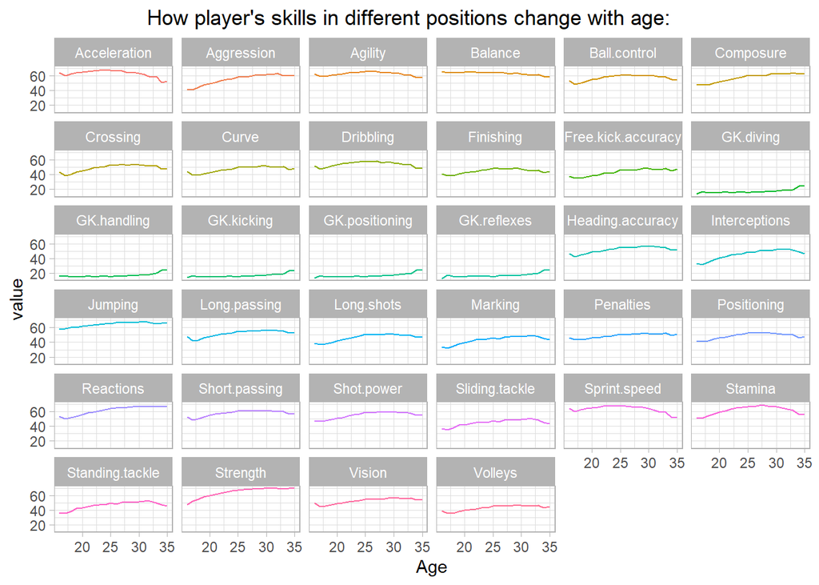

```r
# We'll create a dataframe storing the ages and the skills in order to calculate the means for age:
skills <-fifa_players[,c(3,12:45)]
skills <- filter(.data = skills, Age <= 35)
# Calculate the mean of skills
skills_mean <- aggregate(. ~ Age, data = skills, FUN = mean)
# Convert an object into a molten data frame.
mean_age_skills <-melt(skills_mean,"Age")

ggplot(data=mean_age_skills, aes(x=Age, y=value, group=variable)) +
  geom_line(aes(col=variable)) + theme_light() +
  ggtitle("How player's skills in different positions change with age:") +
  theme(plot.title = element_text(hjust = 0.4))+
  facet_wrap(~variable)+ theme(legend.position="none")
```

We can learn from the graph that the skills which peak at the youngest ages are: Balance, Acceleration, Agility and Sprint speed. The ones that peak at the oldest ages are: Composure, Free kick accuracy, Reactions, Strength and all the different skills for goalkeeprs.  
***  
3.e - Find the $10$ players with the highest difference between their `overall` performance level and the regression model prediction, and list them in a table.

```r
linearModel <- lm(data=fifa, Overall ~ Age+Wage)
predictions <- predict(linearModel, fifa[,c("Age", "Wage")])
fifa$OverallPred <- predictions
fifa$diff <- abs(predictions-fifa$Overall)
arrange(fifa, -diff)[,c("Name", "Overall", "OverallPred", "diff")][1:10,]
```

```
##                 Name Overall OverallPred  diff
## 1  Cristiano Ronaldo      94      159.14 65.14
## 2           L. Messi      93      157.99 64.99
## 3         L. SuÃ¡rez      92      149.15 57.15
## 4            G. Bale      89      124.93 35.93
## 5         L. ModriÄ‡      89      122.41 33.41
## 6     R. Lewandowski      91      123.10 32.10
## 7      B. Richardson      46       77.17 31.17
## 8           T. Kroos      90      120.11 30.11
## 9         S. AgÃ¼ero      89      118.85 29.85
## 10        K. Benzema      86      114.03 28.03
```

Question 4:

4.a - **The first plot** He cleaned the data and presented player’s Club and Nationality. his intention was to show how many different nationalities exist in one team. for example, In AJAX Amsterdam, there are players from 11 different countries.  
**The second plot** In the beginning, He tried to divide each team by the amount of players i.e every nationality in a team is calculated by percentage. Then, he took each nationally in every team (nationality’s percentage number), powered it by 2 and returned the sum of them all. We assume that his intention was to show the ethnic diffusion in each team. as the number DIV grows, the team is less diverse (nationality wise). ***  
4.b - **First problem:** There’s a blank category in both graphs, should be removed because it has no added value to the question he tried to answer.  
**Second problem:** In both graphs, not enough countries are represented in the final result, only the lowest/highest. Thus, We think that histogram would work because it would represent more countries and help us to come up with more significant conclusions.  
**Third problem:** In both graphs, the x axis text is not clear because different categories hide each-other.  
**Fourth problem:** The legend is not very useful. it’s colors are too bright and it’s not easy to find each category in the graph because all the colors look similar. If we presented the graph this way, We’d color the whole bar instead of coloring its border.

4.c - The first change We had to do is to clean the data properly so there won’t be any empty clubs. So we created a new data for both graphs. We added a new library for visualization purposes. to avoid ggplot font errors, We added warning=FALSE at the beginning.

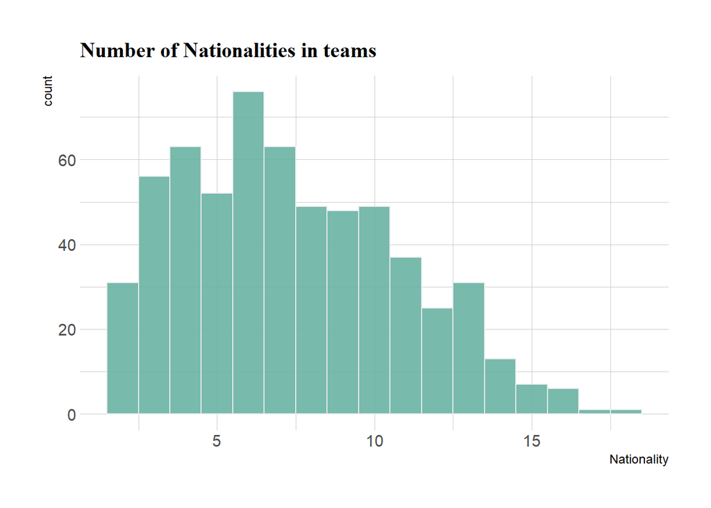

```r
library(hrbrthemes)

#Our corrections of the data:
q4c <- fifa %>% select(Nationality,Club) %>% filter(Club != "") %>% na.omit()

#First code corrections:
number_of_nationality_in_club <- q4c %>% group_by(Club, Nationality) %>% summarise(count = n()) %>% summarise(Nationality=n()) %>% arrange(desc(Nationality))
# Plot correction:
number_of_nationality_in_club %>%
  filter( Nationality > 1 ) %>%
  ggplot( aes(x=Nationality)) +
    geom_histogram( binwidth=1, fill="#69b3a2", color="#e9ecef", alpha=0.9) +
    ggtitle("Number of Nationalities in teams") +
    theme_ipsum() +
    theme(plot.title = element_text(size=15, family= "serif"))
```

The graph above, In contrast to the graph that was shown in the question, represents all the clubs in the dataset. Thus, it’s easier to see the most common quantity of nationalities in a club, which is around 6. By presenting the data in such way, we also solve the forth problem which is unclear legend and the visual problems we found in previous section.  
Simillarly, In the second plot - we used the cleared data and now we’d like to present it in a way that shows all the clubs of the dataset and not only 10. We will be using the same function the function as the fired data-analyst but we will presents the plots differently:

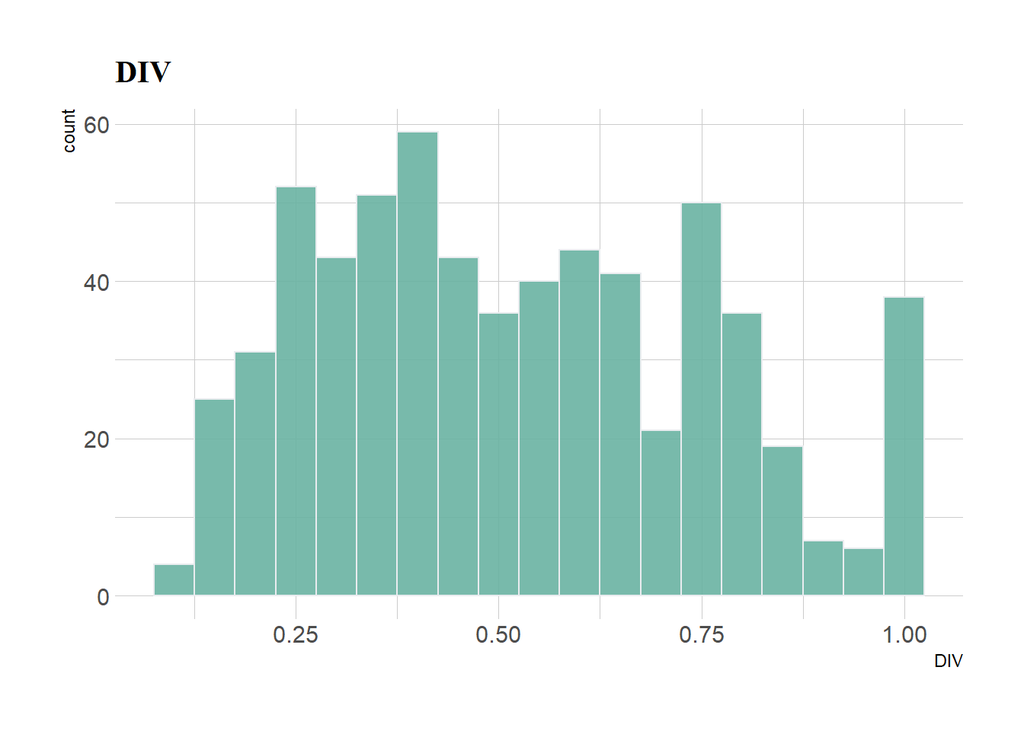

```r
library(hrbrthemes)

# A measure of category's diversity
DIV <- function(category_vec){
  t <- table(category_vec)
  p <- t/sum(t)
  return(sum(p^2))
}
#Second code corrections:
DIV_in_club <- q4c %>% group_by(Club) %>% summarise(DIV = DIV(Nationality))%>% arrange(DIV)
# Plot correction:
DIV_in_club %>%
  ggplot( aes(x=DIV)) +
    geom_histogram( binwidth=0.05, fill="#69b3a2", color="#e9ecef", alpha=0.9) +
    ggtitle("DIV") +
    theme_ipsum() +
    theme(plot.title = element_text(size=15, family= "serif"))
```

This graph shows the amount of clubs in different ranges of DIV values. It represents the whole database and not only a few clubs. If we want a specific DIV value of a club, we can get it from the function output (by filtering the club name). As we did with previous graph, we solved the visual issues (3rd and 4th) by picking a different way of output.